# Lista 1

1. Considere os dados do exercício da aula passada sobre o número de carrapatos encontrados em bezerros. Teste a hipótese de que existe relação entre riqueza de o número de carrapatos e o tamanho do animal.

Número de Carrapatos: 10, 16, 25, 22, 27, 15, 22, 19, 12, 14 Tamanho do Bezerro: 2, 8, 15.5, 16, 20, 12, 16, 12, 4, 6

```r
carrapato<-c(10, 16, 25, 22, 27, 15, 22, 19, 12, 14)
bezerro<-c(2, 8, 15.5, 16, 20, 12, 16, 12, 4, 6)
dados<-data.frame(carrapato,bezerro)
```

## 1 - Ajuste do modelo e interpretação dos coeficientes

```r
m1<-lm(carrapato~bezerro)
m1
```

```
##
## Call:
## lm(formula = carrapato ~ bezerro)
##
## Coefficients:
## (Intercept)      bezerro
##      7.9935       0.9154
```

A equação estimada pelo modelo é dada por $\hat{y}=7.9935+0.9154x_bezerro$. A cada uma unidade de aumento do tamanho do bezerro, observa um aumento de 0.9154 no número de carrapatos.

## 2 - Avalie os testes de significância dos parâmetros do modelo e seus respectivos intervalos de confiança

```r
summary(m1)
```

```
##
## Call:
## lm(formula = carrapato ~ bezerro)
##
## Residuals:
##     Min      1Q  Median      3Q     Max
## -3.9781 -0.4742  0.2604  0.6412  2.8181
##
## Coefficients:
##             Estimate Std. Error t value Pr(>|t|)
## (Intercept)   7.9935     1.2636   6.326 0.000226 ***
## bezerro       0.9154     0.1012   9.049 1.78e-05 ***
## ---
## Signif. codes:  0 '***' 0.001 '**' 0.01 '*' 0.05 '.' 0.1 ' ' 1
##
## Residual standard error: 1.801 on 8 degrees of freedom
## Multiple R-squared:  0.911,  Adjusted R-squared:  0.8999
## F-statistic: 81.88 on 1 and 8 DF,  p-value: 1.781e-05
```

```r
confint(m1)
```

```
##                 2.5 %    97.5 %
## (Intercept) 5.0795343 10.907375
## bezerro     0.6821036  1.148667
```

Com base na estatística de teste que avalia as hipóteses de nulidades dos coeficientes estimados, conclui-se que $\hat{\beta_0}$ e $\hat{\beta_1}$ são diferentes de zero. Ou seja, a variável tamanho do bezerro apresenta um efeito na variação do número de carrapatos. Os intervalos estimados para ambos coeficientes também não apresentam o valor zero.

## 3 - Otenha a ANOVA da Regressão

```r
anova(m1)
```

```
## Analysis of Variance Table
##
## Response: carrapato
##           Df  Sum Sq Mean Sq F value    Pr(>F)
## bezerro    1 265.645 265.645  81.878 1.781e-05 ***
## Residuals  8  25.955   3.244
## ---
## Signif. codes:  0 '***' 0.001 '**' 0.01 '*' 0.05 '.' 0.1 ' ' 1
```

Observa-se na tabela ANOVA que a soma de quadrados da regressão (SQR) é bem superior à soma de quadrado dos resíduos (SQE). A estatística F na regressão linear simples avalia a hipótese $H_0: \beta_1=0$ apresentou o valor de 81.878 o que possibilita rejeitar a hipótese nula e concluir pela significância do modelo ajustado.

## 4 - Avaliação da Adequação do modelo

Nessa etapa serão verificadas as seguintes suposições básicas do MRLS:

- Relação linear entre as variáveis $X$ e $Y$;
- Normalidade de $e_i$, $i = 1, 2, ..., n$;
- Homocedasticidade das variâncias de $e_i$;

**Obtenção dos resíduos do modelo**

```r
#Resíduos Ordinários

r<-residuals(m1)

#Resíduos Padronizados
rp<-rstandard(m1)
```

**Boxplot dos Resíduos**

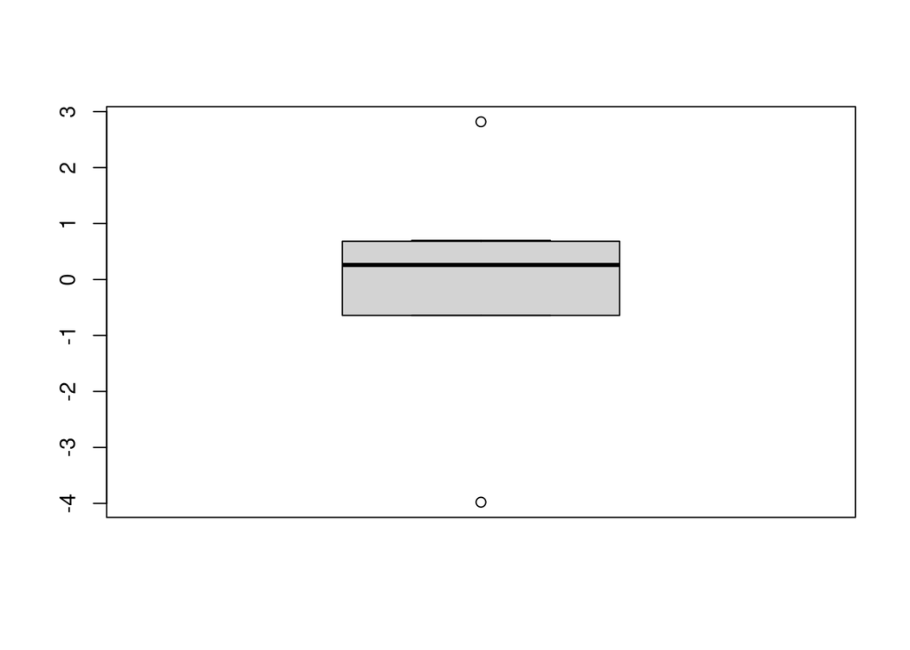

```r
boxplot(r)
```

O boxplot dos resíduos indica a presentaça de valores atípicos mas evidencia uma normalidade nessa distribuição.

**Gráfico normal de probabilidades (QQnorm)** **

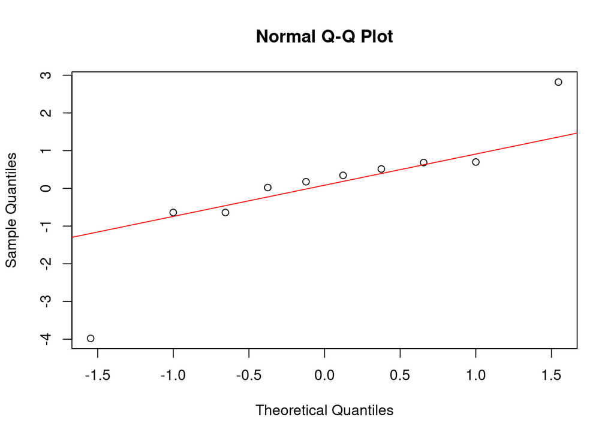

```r
qqnorm(r)
qqline(r, col="red")
```

O gráfico obtido apresenta quase todos os pontos sob a reta e confirma a impressão do boxplot de que os resíduos estão normalmente distribuídos.

**Gráfico dos valores preditos versus os resíduos**

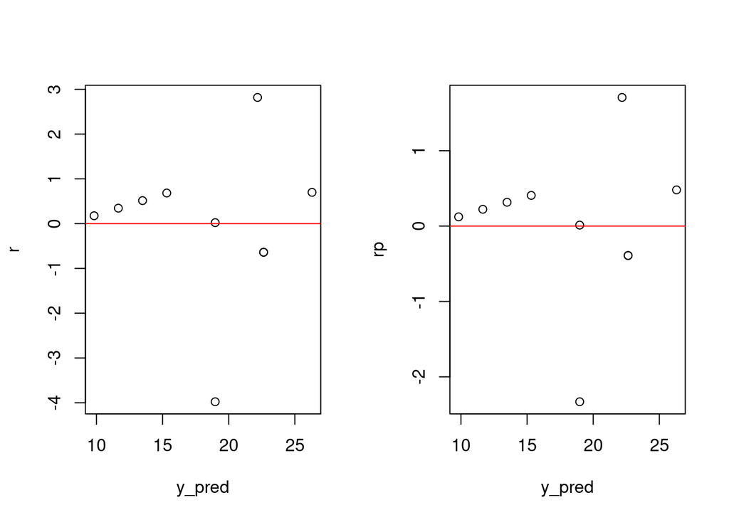

```r
y_pred<-predict(m1)

par(mfrow=c(1,2))
plot(y_pred,r)
abline(h=0, col="red")

plot(y_pred,rp)
abline(h=0, col="red")
```

Os gráficos indicam uma violação no pressuposto da linearidade pois não há um padrão constante na distribuição dos pontos ao redor da reta.

**Gráfico dos valores da variável regressora versus os resíduos**

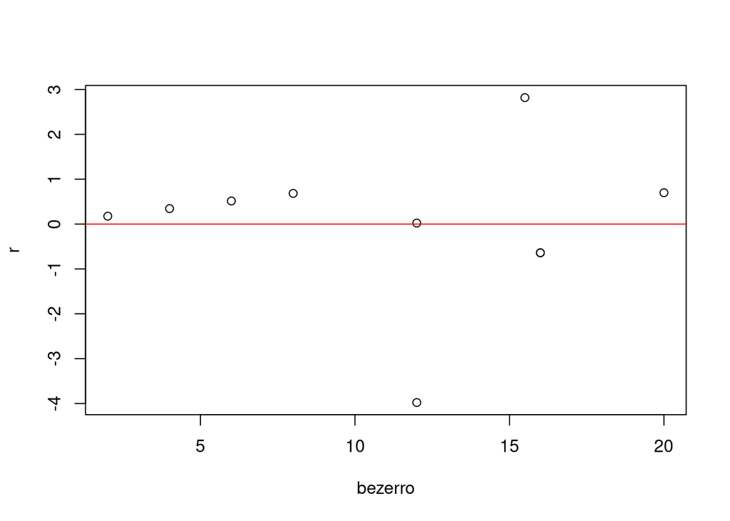

```r
plot(bezerro,r)
abline(h=0, col="red")
```

Na regressão linear simples esse gráfico é equivalente ao gráfico anterior dos valores preditos versus os resíduos. Nota-se que o pressuposto da homocedasticidade foi violado pois a variabilidade dos resíduos não é constante ao longo dos valores da variável regressora bezerro.

**Resumo dos gráficos de adequação dos resíduos**

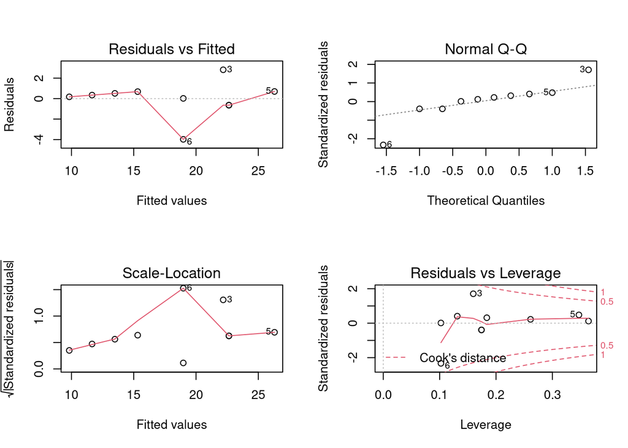

```r
par(mfrow=c(2,2))
plot(m1)
```

A informação adicional revelada por esse conjunto de gráficos refere-se ao último gráfico que plota os resíduos contra os valores leverage, uma medida que permite identificar valores atípicos e que podem influenciar o ajuste dos coeficientes. Pelo gráfico os valores ficaram dentro do esperado.

## 5 - Adoção de Medidas Corretivas

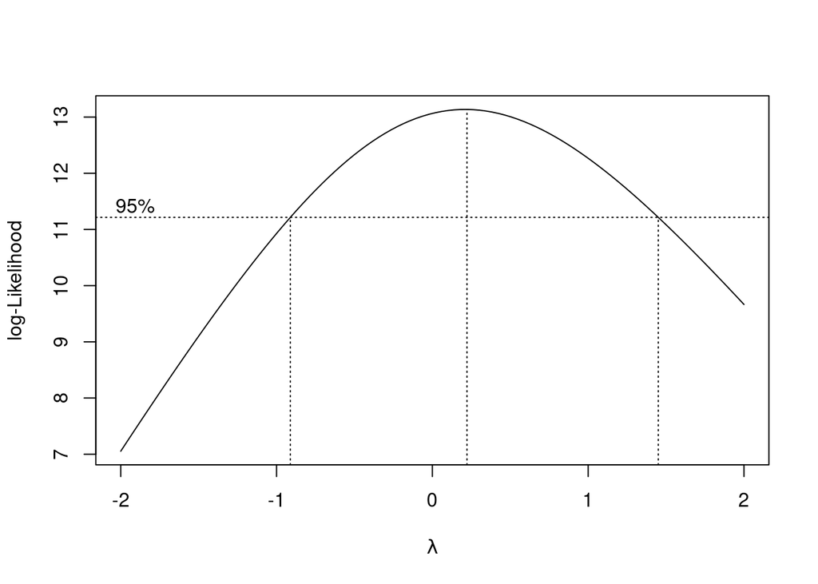

```r
library(MASS)
bc<-boxcox(m1)
```

```r
(lambda<-bc$x[which.max(bc$y)])
```

```
## [1] 0.2222222
```

```r
lambda
```

```
## [1] 0.2222222
```

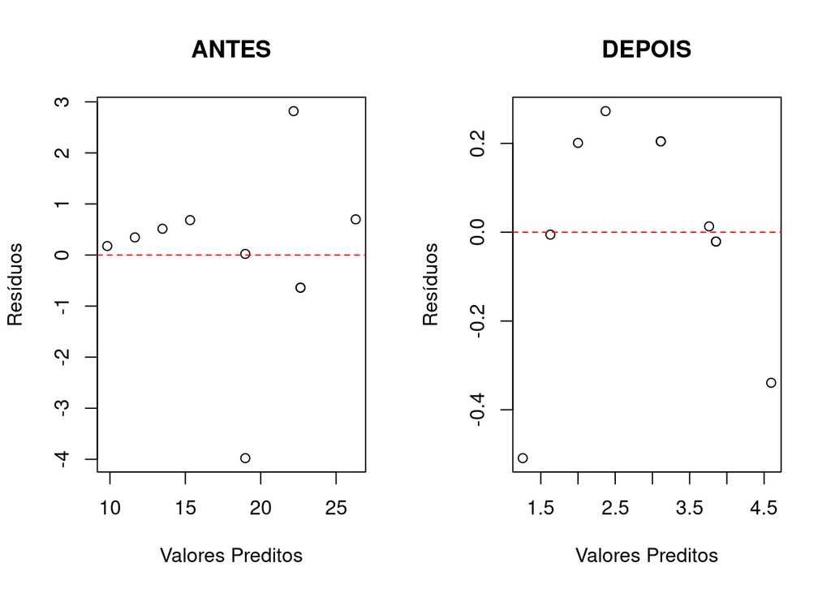

```r
#Aplicação da transformação boxcox em Y
carrapato2<- (bezerro^(lambda) - 1)/lambda

#Ajuste do modelo com variável transformada
m2<-lm(carrapato2~bezerro)


#comparação do gráfico predito vs resíduos antes e depois da transformação
par(mfrow=c(1,2))
plot(m1$fitted.values,m1$residuals,xlab="Valores Preditos",ylab="Resíduos",main="ANTES")
abline(h=0, lwd=1, lty=2, col="red")

plot(m2$fitted.values,m2$residuals,xlab="Valores Preditos",ylab="Resíduos",main="DEPOIS")
abline(h=0, lwd=1, lty=2, col="red")
```

O gráfico realizado com o ajuste do modelo para a variável transformada parece não ter apresentado mudanças expressivas. Pode-se questionar se a transformação não foi a melhor, ou o tamanho pequeno do conjunto, ou ainda pode-se realizar um teste estatístico para avaliar a violação dessa supoição.

```r
#Teste de Breusch- Pagan

library(lmtest)
bptest(m2)
```

```
##
##  studentized Breusch-Pagan test
##
## data:  m2
## BP = 1.6037, df = 1, p-value = 0.2054
```

O teste de Breusch-Pagan cuja hipótese nula estabele que as variâncias são constantes não apresentou evidências para a rejeição dessa hipótese.

#——————————————

# Resolução Exercício 2

Foi realizado um levantamento com indicadores sobre a riqueza de espécies de parasitas em 17 ilhas do Arquipélago de de Galápagos em função do tamanho dessas localidades.

```r
dados<-read.csv("~/Google Drive/UFRRJ/Modelos Regressão 2021/Listas/galapago.csv")
str(dados)
```

```
## 'data.frame':    17 obs. of  2 variables:
##  $ area    : num  7498 213 650 677 1297 ...
##  $ parasita: int  325 319 306 224 193 119 103 80 79 52 ...
```

##1. Construa um diagrama de dispersão

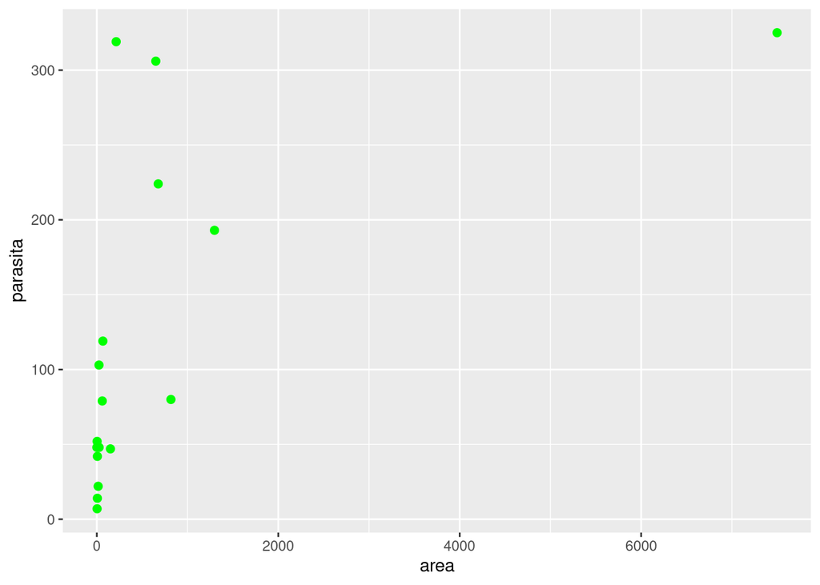

```r
library(ggplot2)
ggplot(dados, aes(x=area, y=parasita))+
  geom_point(size=2,col="green")
```

##2. Ajuste um modelo de regressão linear simples aos dados

```r
m1<-lm(parasita~area,data=dados)

summary(m1)
```

```
##
## Call:
## lm(formula = parasita ~ area, data = dados)
##
## Residuals:
##    Min     1Q Median     3Q    Max
## -88.55 -53.66 -43.56  21.21 216.04
##
## Coefficients:
##             Estimate Std. Error t value Pr(>|t|)
## (Intercept) 95.44426   24.38397   3.914  0.00138 **
## area         0.03522    0.01303   2.703  0.01636 *
## ---
## Signif. codes:  0 '***' 0.001 '**' 0.01 '*' 0.05 '.' 0.1 ' ' 1
##
## Residual standard error: 93.72 on 15 degrees of freedom
## Multiple R-squared:  0.3275, Adjusted R-squared:  0.2827
## F-statistic: 7.306 on 1 and 15 DF,  p-value: 0.01636
```

```r
anova(m1)
```

```
## Analysis of Variance Table
##
## Response: parasita
##           Df Sum Sq Mean Sq F value  Pr(>F)
## area       1  64179   64179  7.3061 0.01636 *
## Residuals 15 131764    8784
## ---
## Signif. codes:  0 '***' 0.001 '**' 0.01 '*' 0.05 '.' 0.1 ' ' 1
```

O modelo, porém, apresentou um baixo coeficiente de determinação igual a 32,75%.

#3. Faça o diagnóstico. O ajuste foi adequado ?

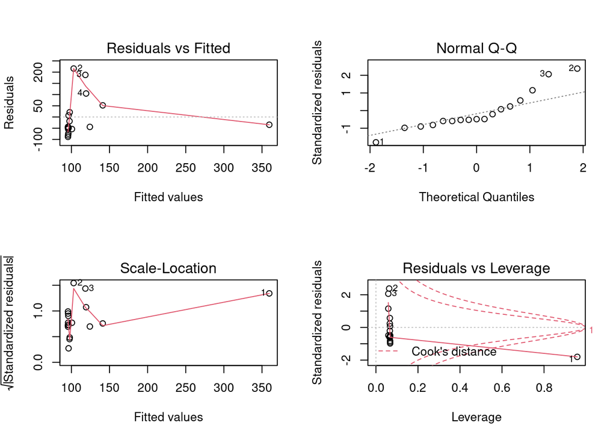

```r
par(mfrow=c(2,2))
plot(m1)
```

Observa-se violação da normalidade (assimetria postiva), da homocedasticidade e da linearidade. Também foi identificado um valor considerado atípico.

# 4. Caso não seja adequado, use o procedimento Box-Cox para encontrar uma transformação satisfatória.

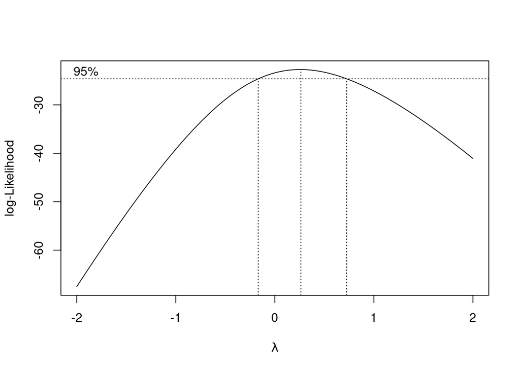

```r
library(MASS)
bc<-boxcox(m1)
```

```r
(lambda<-bc$x[which.max(bc$y)])
```

```
## [1] 0.2626263
```

Tendo o valor de lambda situado entre 0 e 0,5 iremos adotar uma transformação logaritma por ser mais usual.

# 5. Refaça o ajuste e o diagnóstico. É válido agora?

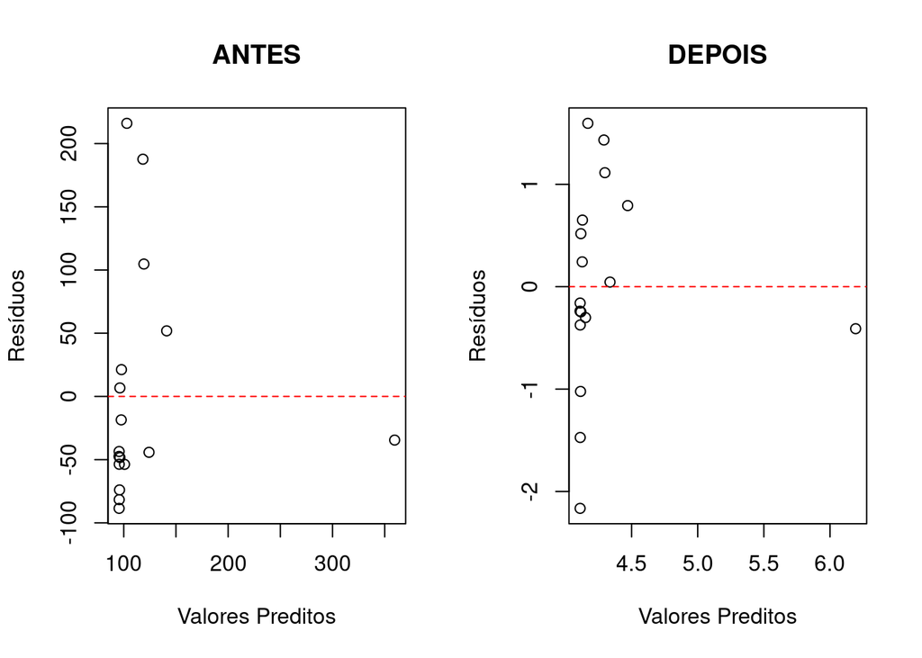

```r
#Aplicação da transformação boxcox em Y
dados$parasita2<- log(dados$parasita)

#Ajuste do modelo com variável transformada
m2<-lm(parasita2~area, data = dados)


#comparação do gráfico predito vs resíduos antes e depois da transformação
par(mfrow=c(1,2))
plot(m1$fitted.values,m1$residuals,xlab="Valores Preditos",ylab="Resíduos",main="ANTES")
abline(h=0, lwd=1, lty=2, col="red")

plot(m2$fitted.values,m2$residuals,xlab="Valores Preditos",ylab="Resíduos",main="DEPOIS")
abline(h=0, lwd=1, lty=2, col="red")
```

A distribuição dos resíduos ainda permance com indicação de violação dos pressupostos do modelo.

# 6. Você pode também transformar AMBAS as variáveis: tente transformar ambas as variáveis usando log e reconstrua o diagrama de dispersão, ajuste uma regressão e faça o diagnóstico. Melhorou ?

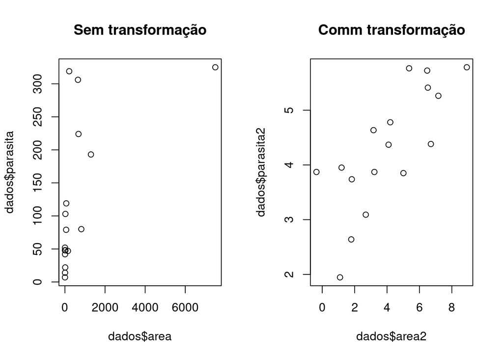

```r
dados$area2<-log(dados$area)

par(mfrow=c(1,2))

plot(dados$area,dados$parasita, main = "Sem transformação")
plot(dados$area2,dados$parasita2, main = "Comm transformação")
```

Após a transformação logaritimica de ambas as variáveis é possível observar com mais clareza a relaão linerar existente entre elas.

```r
m3<-lm(parasita2~area2, data=dados)
summary(m3)
```

```
##
## Call:
## lm(formula = parasita2 ~ area2, data = dados)
##
## Residuals:
##      Min       1Q   Median       3Q      Max
## -1.36918 -0.75099  0.06106  0.60455  1.03864
##
## Coefficients:
##             Estimate Std. Error t value Pr(>|t|)
## (Intercept)  2.95083    0.34257   8.614 3.43e-07 ***
## area2        0.33157    0.07193   4.609 0.000341 ***
## ---
## Signif. codes:  0 '***' 0.001 '**' 0.01 '*' 0.05 '.' 0.1 ' ' 1
##
## Residual standard error: 0.7365 on 15 degrees of freedom
## Multiple R-squared:  0.5862, Adjusted R-squared:  0.5586
## F-statistic: 21.25 on 1 and 15 DF,  p-value: 0.0003406
```

Os coeficientes do modelo ajustado são estatisticamente significativos e houve melhora no coeficiente de determinação. No entanto, a análise dos dados está em escala logarítmica .

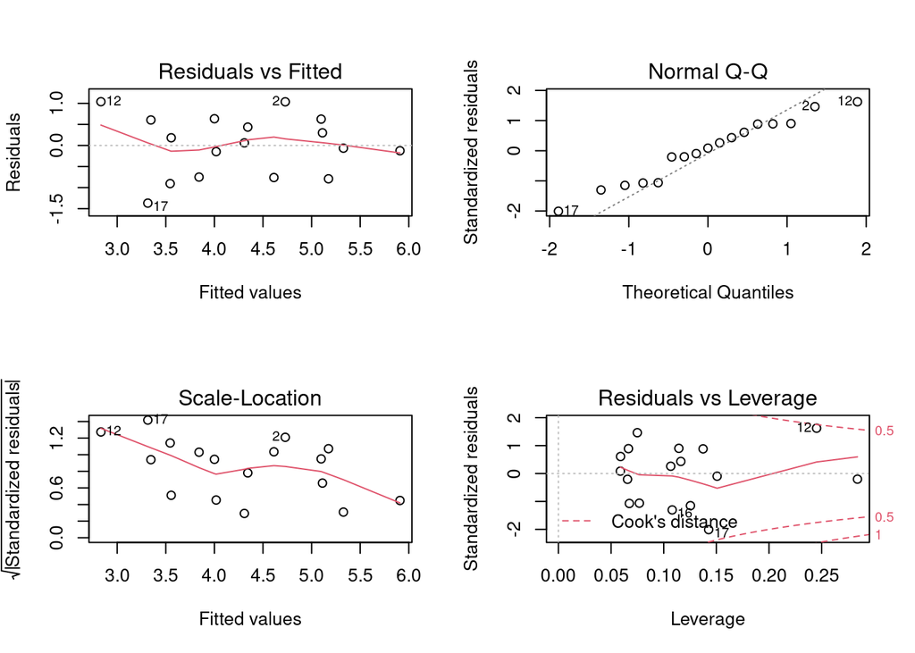

```r
par(mfrow=c(2,2))
plot(m3)
```

Houve uma expressiva melhora na qualidade dos gráficos obtidos com a nova modelagem.

```r
library(lmtest)
bptest(m3)
```

```
##
##  studentized Breusch-Pagan test
##
## data:  m3
## BP = 3.5901, df = 1, p-value = 0.05813
```